# Week 1 Study Guide

Eric Schmidt

2026-11-25

# Chapter 1: Introduction to Statistics

## 1.1 Statistics in Business

- **Definition of Statistics:** The science dealing with the collection, analysis, interpretation, and presentation of numerical data to convert raw data into useful information for managerial decision making.
- **Business Applications:** Used across corporate functional areas including marketing consumer surveys, operations quality tracking, teleworking productivity, and retail spend analysis.

## 1.2 Basic Statistical Concepts

- Two Major Branches:
  - **Descriptive Statistics:** Techniques used to summarize, organize, and reach conclusions solely about the specific group or dataset observed.
  - **Inferential Statistics (Inductive Statistics):** Gathering data from a sample to make estimates, inferences, or test hypotheses about the larger population.
- Core Terminology:
  - **Population:** The complete collection of persons, objects, or items under study.
  - **Census:** Gathering data from an entire population.
  - **Sample:** A representative portion of the population selected for analysis.
  - **Parameter:** A descriptive measure computed from an entire population, traditionally denoted by Greek letters ($\mu$, $\sigma^2$, $\sigma$).
  - **Statistic:** A descriptive measure computed from sample data, traditionally denoted by Roman letters ($\bar{x}$, $s^2$, $s$).

## 1.3 Data Measurement Levels

- Nonmetric / Qualitative Data:
  - **Nominal Level:** Numbers or labels used strictly to classify, categorize, or identify entities (e.g., employee ID, gender, geographic region, phone area code). No inherent ranking or arithmetic value.
  - **Ordinal Level:** Data that can be ranked or ordered, but distances or spacing between adjacent ranks are unequal or non-quantifiable (e.g., customer satisfaction Likert scales, Fortune 500 company rankings, credit risk ratings).
- Metric / Quantitative Data:
  - **Interval Level:** Numerical data where differences between consecutive numbers represent equal distances, but the zero point is arbitrary and does not signify the absence of the attribute (e.g., Fahrenheit temperature, percentage return on stock).
  - **Ratio Level:** Highest level of measurement containing all properties of interval data with a natural, absolute zero point signifying the absence of the characteristic (e.g., dollar sales, cycle time, weight, employee headcounts).
  - **Parametric vs. Nonparametric Techniques:** Parametric statistics require interval or ratio data and distributional assumptions; nominal and ordinal data require nonparametric methods.

```r
department <- factor(c("Educator", "Manufacturing", "Lawyer", "Educator"))
is.factor(department)
```

```
## [1] TRUE
```

```r
is.ordered(department)
```

```
## [1] FALSE
```

```r
satisfaction <- factor(
  c("Somewhat Helpful", "Very Helpful", "Not Helpful", "Extremely Helpful"),
  levels = c(
    "Not Helpful",
    "Somewhat Helpful",
    "Moderately Helpful",
    "Very Helpful",
    "Extremely Helpful"
  ),
  ordered = TRUE
)

satisfaction[2] > satisfaction[1]
```

```
## [1] TRUE
```

```r
sales_volume <- c(629, 504, 246, 172, 120)
summary(sales_volume)
```

```
##    Min. 1st Qu.  Median    Mean 3rd Qu.    Max.
##   120.0   172.0   246.0   334.2   504.0   629.0
```

# Chapter 2: Charts and Graphs

## 2.1 Frequency Distributions

- **Ungrouped vs. Grouped Data:** Ungrouped data are raw, unsummarized observations; grouped data are organized into classes and frequencies.
- Steps in Constructing a Frequency Distribution:
  1. Determine the range ($Range = \text{Maximum} - \text{Minimum}$).
  2. Select the number of classes (typically 5 to 15 classes).
  3. Approximate class width ($\text{Width} \approx \frac{\text{Range}}{\text{Number of Classes}}$, usually rounded up).
  4. Establish non-overlapping class boundaries.
- Frequency Metrics:
  - **Class Midpoint (Class Mark):** The average of the lower and upper endpoints of a class interval: $M = \frac{\text{Lower} + \text{Upper}}{2}$.
  - **Relative Frequency:** The proportion of total frequency falling in an  
    individual class: $\frac{f}{N}$.
  - **Cumulative Frequency:** A running total of frequencies across sequential classes.

```r
unemp <- c(
  2.3, 7.0, 6.3, 11.3, 9.6,  2.8, 7.1, 5.6, 10.6, 9.1,
  3.6, 5.4, 5.9, 9.7, 8.3,   2.4, 5.5, 7.1, 8.8, 7.6,
  2.9, 7.1, 4.7, 7.8, 6.8,   3.0, 8.0, 3.9, 7.5, 7.2,
  4.6, 3.6, 8.4, 8.1, 7.7,   4.4, 4.1, 7.5, 10.3, 7.6,
  3.4, 4.8, 7.5, 11.2, 7.2,  4.6, 4.7, 7.6, 11.4, 6.8,
  6.9, 11.0, 5.9, 10.4, 6.3, 6.0, 12.0, 6.4, 9.5, 6.0
)

unemp_range <- max(unemp) - min(unemp)
n_classes <- 6
approx_width <- unemp_range / n_classes
class_width <- ceiling(approx_width)
print(sprintf("Range = %.1f | Approx Width (6 classes) = %.2f | Rounded Width = %d",
              unemp_range, approx_width, class_width))
```

```
## [1] "Range = 9.7 | Approx Width (6 classes) = 1.62 | Rounded Width = 2"
```

```r
bins <- seq(1, 13, by = class_width)
classes <- cut(unemp, breaks = bins, right = FALSE)

freq_table <- data.frame(table(Class = classes))
freq_table$Midpoint <- (bins[-length(bins)] + bins[-1]) / 2
freq_table$Rel_Freq <- round(freq_table$Freq / sum(freq_table$Freq), 4)
freq_table$Cum_Freq <- cumsum(freq_table$Freq)

print(freq_table)
```

```
##     Class Freq Midpoint Rel_Freq Cum_Freq
## 1   [1,3)    4        2   0.0667        4
## 2   [3,5)   12        4   0.2000       16
## 3   [5,7)   13        6   0.2167       29
## 4   [7,9)   19        8   0.3167       48
## 5  [9,11)    7       10   0.1167       55
## 6 [11,13)    5       12   0.0833       60
```

## 2.2 Quantitative Data Graphs

- **Histogram:** A series of contiguous rectangles whose widths represent class intervals along a numerical scale and heights represent class frequencies.
- **Frequency Polygon:** A line graph constructed by placing a dot at each class  
  frequency directly above the class midpoint, then connecting the dots sequentially.
- **Ogive:** A cumulative frequency polygon plotted at class endpoints starting at zero on the lower boundary of the first interval. Used to inspect running totals and identify steep rate increases.
- **Dot Plot:** Displays individual observations as dots stacked vertically along a single numerical horizontal axis; useful for spotting clusters, gaps, and outliers in small-to-moderate datasets.
- **Stem-and-Leaf Plot:** Separates data digits into a leading stem (higher-order digits) and trailing leaf (lower-order digits), retaining the original raw data values while visually portraying the distribution.

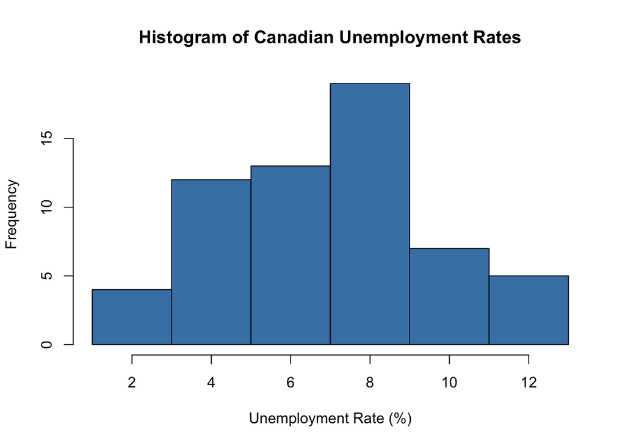

```r
hist(unemp, breaks = seq(1, 13, by = 2), right = FALSE,
     col = "steelblue", xlab = "Unemployment Rate (%)",
     main = "Histogram of Canadian Unemployment Rates")
```

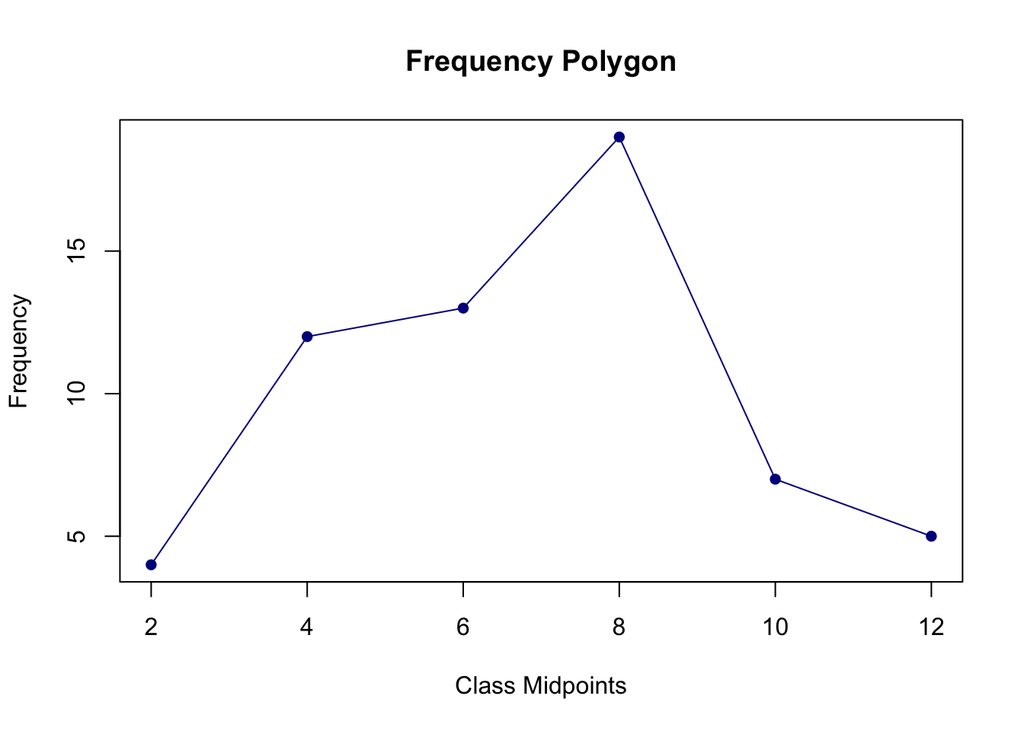

```r
h <- hist(unemp, breaks = seq(1, 13, by = 2), plot = FALSE, right = FALSE)
plot(h$mids, h$counts, type = "o", pch = 16, col = "darkblue",
     xlab = "Class Midpoints", ylab = "Frequency",
     main = "Frequency Polygon")
```

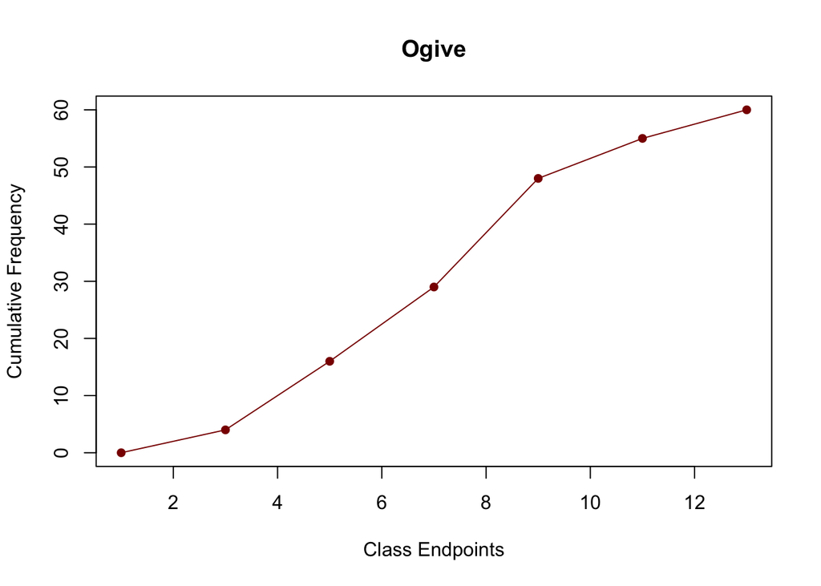

```r
cum_counts <- c(0, cumsum(h$counts))
plot(bins, cum_counts, type = "o", pch = 16, col = "darkred",
     xlab = "Class Endpoints", ylab = "Cumulative Frequency",
     main = "Ogive")
```

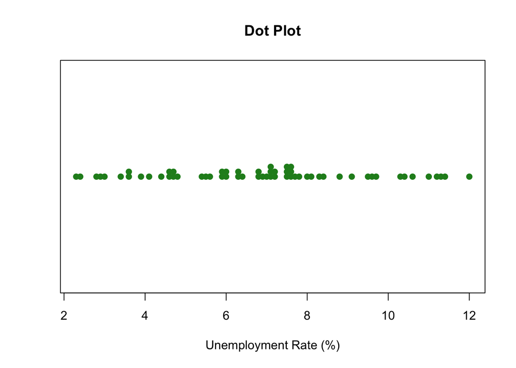

```r
stripchart(unemp, method = "stack", pch = 19, col = "forestgreen",
           xlab = "Unemployment Rate (%)", main = "Dot Plot")
```

```r
stem(unemp, scale = 1)
```

```
##
##   The decimal point is at the |
##
##    2 | 3489
##    3 | 04669
##    4 | 1466778
##    5 | 45699
##    6 | 00334889
##    7 | 01112255566678
##    8 | 01348
##    9 | 1567
##   10 | 346
##   11 | 0234
##   12 | 0
```

## 2.3 Qualitative Data Graphs

- **Pie Chart:** Circular depiction dividing $360^\circ$ proportionally to show the percentage breakdown of subcategories to the whole ($Degrees = Proportion \times 360^\circ$).
- **Bar Graph (or Column Chart):** Displays categorical variables along one axis and rectangular bars along the other axis representing magnitude, frequency, or percentage. Superior to pie charts when discriminating between categories with similar magnitudes.
- **Pareto Chart:** Vertical bar chart used in Total Quality Management (TQM) displaying causes of defects ranked in descending order from left to right, often overlaid with a cumulative percentage line. Separates the “vital few” defects from the “trivial many”.

```r
channels <- c("Supermarket", "Fountain", "Convenience/Gas", "Vending", "Mass Merch", "Drugstore")
market_share <- c(44, 24, 16, 11, 3, 2)
pie_degrees <- (market_share / sum(market_share)) * 360
print(data.frame(Channel = channels, Share_Pct = market_share, Degrees = pie_degrees))
```

```
##           Channel Share_Pct Degrees
## 1     Supermarket        44   158.4
## 2        Fountain        24    86.4
## 3 Convenience/Gas        16    57.6
## 4         Vending        11    39.6
## 5      Mass Merch         3    10.8
## 6       Drugstore         2     7.2
```

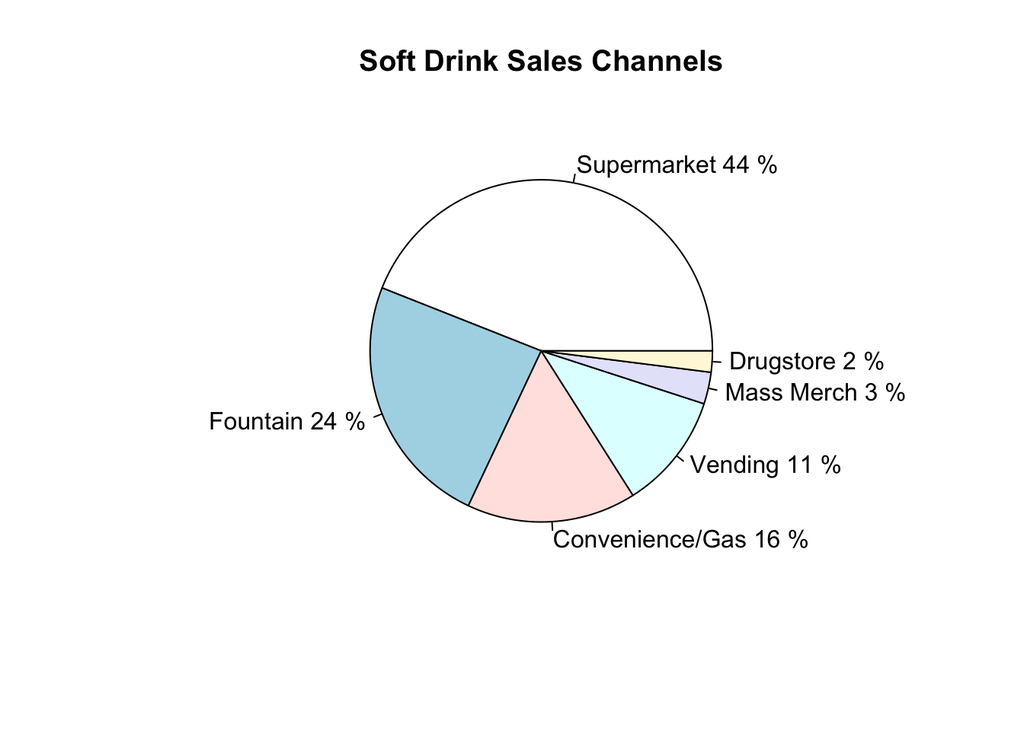

```r
pie(market_share, labels = paste(channels, market_share, "%"),
    main = "Soft Drink Sales Channels")
```

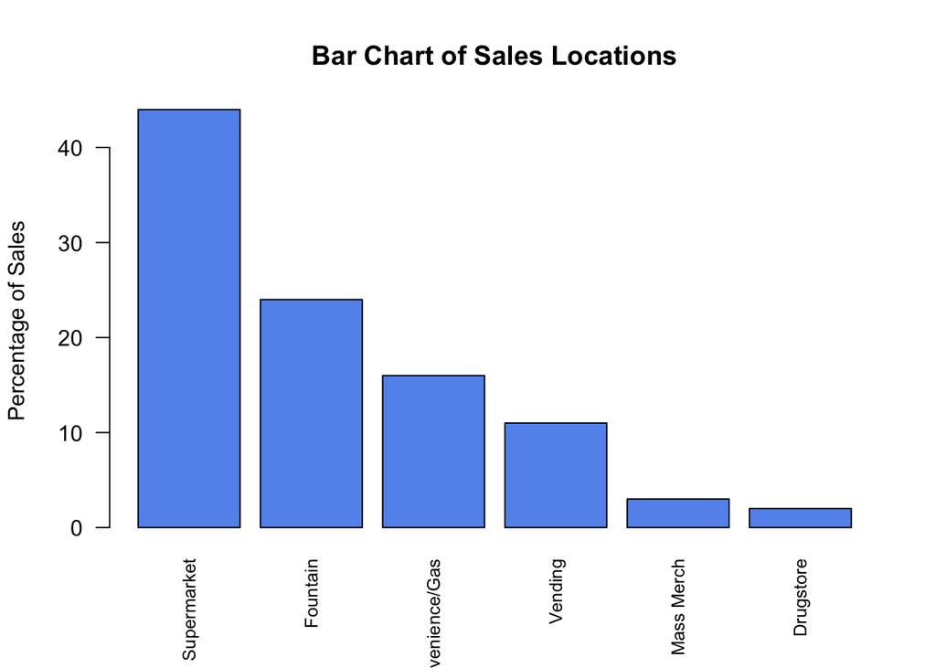

```r
barplot(market_share, names.arg = channels, col = "cornflowerblue",
        las = 2, ylab = "Percentage of Sales", cex.names = 0.8,
        main = "Bar Chart of Sales Locations")
```

```r
defect_counts <- c(Poor_Wiring = 40, Short_Coil = 30, Defect_Plug = 25, Bearings = 5)
sorted_counts <- sort(defect_counts, decreasing = TRUE)
cum_counts_pareto <- cumsum(sorted_counts)
cum_pct <- cum_counts_pareto / sum(sorted_counts) * 100
print(data.frame(Defect = names(sorted_counts), Count = as.numeric(sorted_counts), Cum_Pct = cum_pct))
```

```
##                  Defect Count Cum_Pct
## Poor_Wiring Poor_Wiring    40      40
## Short_Coil   Short_Coil    30      70
## Defect_Plug Defect_Plug    25      95
## Bearings       Bearings     5     100
```

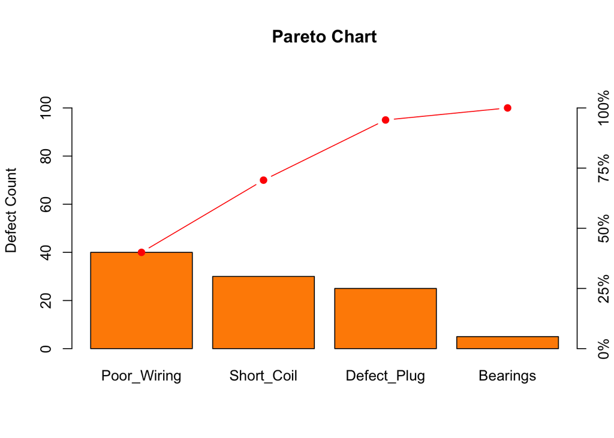

```r
bp <- barplot(sorted_counts, ylim = c(0, sum(sorted_counts) * 1.15),
              col = "darkorange", ylab = "Defect Count", main = "Pareto Chart")
lines(bp, cum_counts_pareto, type = "b", pch = 19, col = "red")
axis(side = 4, at = seq(0, 100, by = 25) * sum(sorted_counts) / 100, labels = paste0(seq(0, 100, by = 25), "%"))
```

## 2.4 Scatter Plots for Two-Variable Numerical Data

- **Definition:** A two-dimensional plot of paired numerical observations $(x, y)$ on Cartesian axes.
- **Purpose:** Provides an exploratory visual display to detect directional patterns, linear or non-linear tendencies, dispersion, and outliers between two continuous variables.

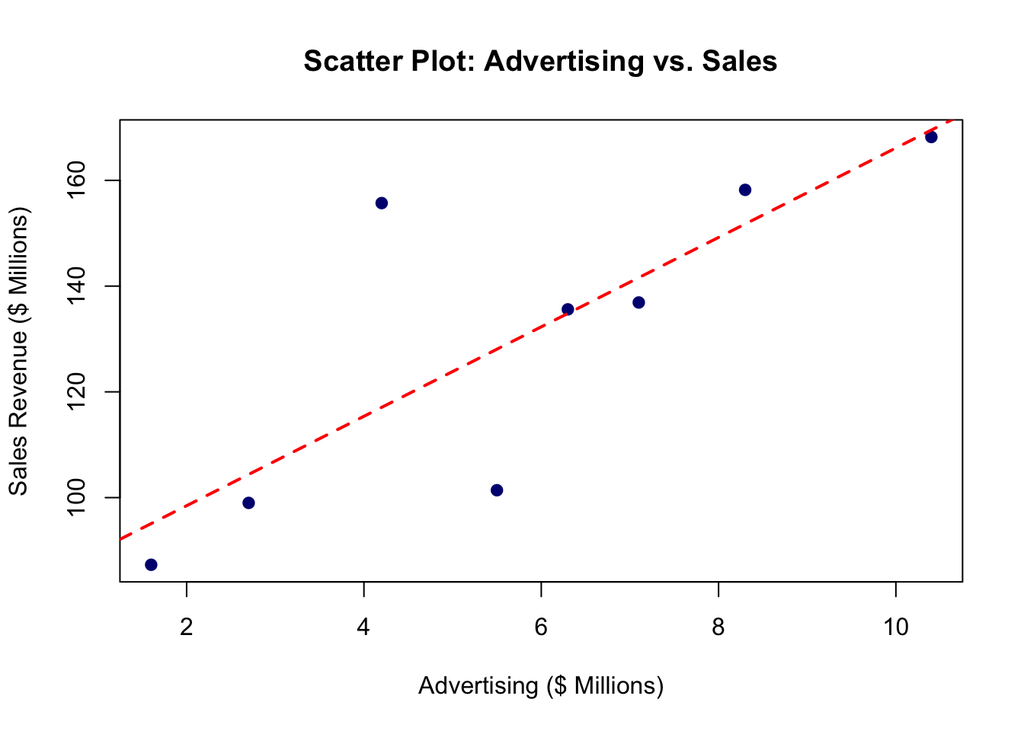

```r
advertising <- c(4.2, 1.6, 6.3, 2.7, 10.4, 7.1, 5.5, 8.3)
sales_revenue <- c(155.7, 87.3, 135.6, 99.0, 168.2, 136.9, 101.4, 158.2)

plot(advertising, sales_revenue,
     pch = 19, col = "navy",
     xlab = "Advertising ($ Millions)",
     ylab = "Sales Revenue ($ Millions)",
     main = "Scatter Plot: Advertising vs. Sales")

abline(lm(sales_revenue ~ advertising), col = "red", lwd = 2, lty = 2)
```

## Ethical Considerations in Data Presentation

- Selecting honest, non-manipulative bin widths and class bounds for frequency distributions to avoid misrepresenting dispersion.
- Avoiding the use of stretched, compressed, or truncated axes on histograms and line graphs to exaggerate or downplay trends.
- Using appropriate analytical models calibrated directly to the level of data measurement (i.e., avoiding parametric computations on purely nominal or ordinal classifications).

## Navigation & Practice

- **Next Lesson:** Week 2 Study Guide — Descriptive Statistics & Modern Robust Analytics